# InVivoStat Graphics

## Selected variables

The variable Resp 1 has been selected as the response and the variable Time 1 has been selected to define the X-axis. The variable Resp 1 has been log10 transformed. The variable Cat2 has been selected as the categorisation factor. The variable Animal2 defines the case profiles.

## Categorised case profiles plot

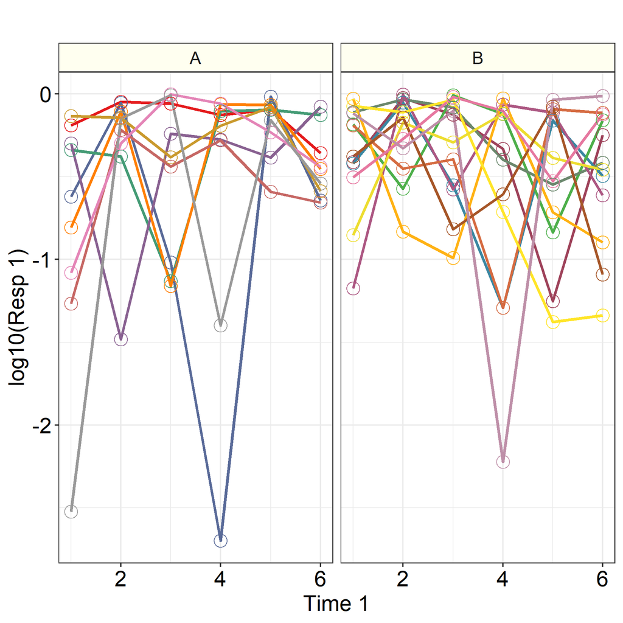

For more information on the theoretical approaches that are implemented within this module, see Bate and Clark (2014).

## References

When referring to InVivoStat, please cite 'InVivoStat, version 4.9'.

Bate, S.T. and Clark, R.A. (2014). The Design and Statistical Analysis of Animal Experiments. Cambridge University Press.

#### R references

R Core Team (2022). R: A language and environment for statistical computing. R Foundation for Statistical Computing, Vienna, Austria. URL https://www.R-project.org/.